# Data wrangling

GEOG 30323

February 20, 2024

### Data wrangling

In real-world data analysis, your data will likely:

- Have missing/possibly incorrect values
- Be in a format unsuitable for data analysis
- Be spread across multiple files, possibly of different types
- Need re-shaping or summarization to draw meaningful conclusions

Fortunately, `pandas` can help you with all of this!

### Subsetting

- Frequently, you’ll have way more data than you need!
- Datasets can be reduced in size by **indexing** and **subsetting**
- Let’s read in the colleges dataset as a demo

```python
import pandas as pd

full_url = 'http://personal.tcu.edu/kylewalker/data/colleges.csv'
full_df = pd.read_csv(full_url, encoding = 'latin_1')
full_df.shape
```

### By column name

- Let’s drop most of the columns in the dataset with `.filter()`

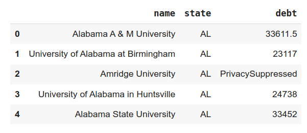

```python
cols_to_keep = ['INSTNM', 'STABBR', 'GRAD_DEBT_MDN_SUPP']
debt_df = full_df.filter(cols_to_keep)
debt_df.columns = ['name', 'state', 'debt']
debt_df.head()
```

### By row position

- Data frames can be *sliced* like lists and strings

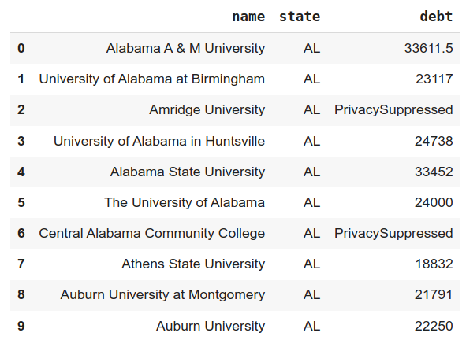

```python
# Retain row 0 up until but not including row 10
debt_df[0:10]
```

### By row or column index

- Selecting by row or column index available in the `.loc[]` method (note the brackets)

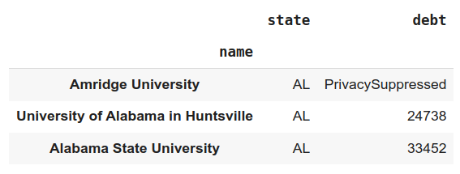

```python
example1 = debt_df.set_index('name')
example1.loc['Amridge University':'Alabama State University']
```

### By value

- Often, you’ll want to *keep* rows that have a certain column value, or *exclude* rows based on that value
- The data frame method `.query()` will “query” your dataset based on an expression
- Expressions use **conditional operators**; can be combined with `&` (and) and `|` (or)

### By value

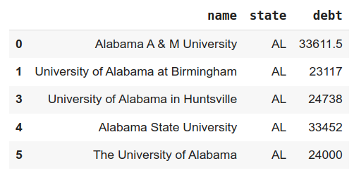

```python
debt_df1 = debt_df.query("debt != 'PrivacySuppressed'")
debt_df1.head()
```

### By value

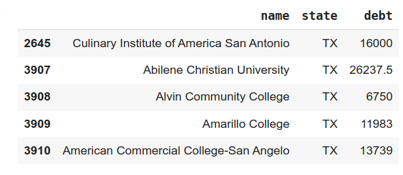

```python
tx_debt_df = debt_df.query('debt != "PrivacySuppressed" & state == "TX" ')
tx_debt_df.head()

# Alternatively, use an index-based method

# tx_debt_df = debt_df.loc[(debt_df['debt'] != 'PrivacySuppressed') & (debt_df['state'] == 'TX')]
```

### By value

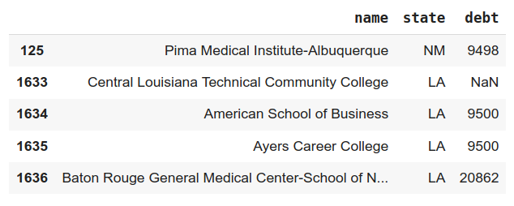

```python
states = ['OK', 'NM', 'TX', 'LA']
# Use `in @states` to get values in the list
# @ operator allows for use of variables in the query
sw_debt_df = debt_df.query("debt != 'PrivacySuppressed' & state in @states")

sw_debt_df.head()
```

### Creating new columns

- New columns can be created based on specified values, or as derivatives of other columns, using mathematical operators or the `.assign()` method
- Let’s demo with a simulated data frame:

```python
import numpy as np
np.random.seed(1983)

df1 = pd.DataFrame({'col1': np.random.randint(1, 100, 10),
                    'col2': np.random.randint(1, 100, 10),
                    'col3': np.random.randint(1, 100, 10)})
```

### Creating new columns

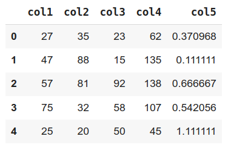

```python
# With .assign()
df2 = df1.assign(col4 = df1.col1 + df1.col2)

# With index-based labeling
df2['col5'] = df2['col3'] / df2['col4']

df2.head()
```

### `dtype` conversion

- To do numerical analysis, our numeric data have to be stored as numbers!
- To convert: use the `.astype()` method

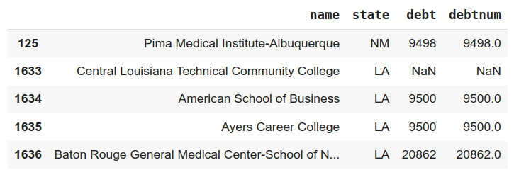

```python
sw_debt_num = sw_debt_df.assign(debtnum = sw_debt_df.debt.astype(float))

sw_debt_num.head()
```

### Missing data

- Commonly, all of the data you need will not be found in your data set!
- Possible solutions:
  - Delete all rows that have missing data
  - Fill in missing data with a specified value
  - **Interpolate** missing values

### Missing data

- `.dropna()` method: delete all rows (or columns) that have any missing values (`NaN` in `pandas`)

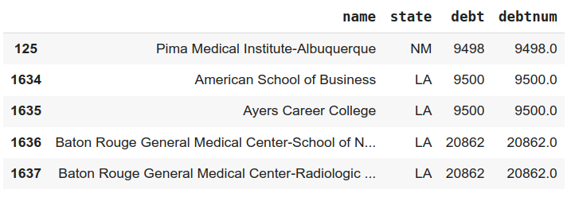

```python
sw_debt_clean = sw_debt_num.dropna()

sw_debt_clean.head()
```

### Missing data

- `.fillna()` method: fill in missing data with a specified value

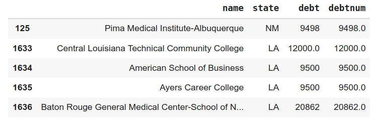

```python
sw_debt_fill = sw_debt_num.fillna(sw_debt_num.median())

sw_debt_fill.head()
```

### Method chaining

- **pandas** data wrangling methods can be “chained” together to compute a data wrangling workflow all at once

```python
cols_to_keep = ['INSTNM', 'STABBR', 'GRAD_DEBT_MDN_SUPP']
states = ['OK', 'NM', 'TX', 'LA']

sw_debt_clean = (full_df
  .filter(cols_to_keep)
  .set_axis(['name', 'state', 'debt'], axis = 'columns')
  .query("debt != 'PrivacySuppressed' & state in @states")
  .assign(debtnum = lambda x: x.debt.astype(float))
  .dropna()
)
```

### Group-wise data analysis

- Thus far, we’ve focused on characteristics of data within a particular group
- Common question: how do characteristics vary by group?
- In `pandas`: `.groupby()` method!

### Split-apply-combine

- Wickham (2011): the “split-apply-combine” model of data analysis

Process:

- Data are **split** by some characteristic into groups
- We **apply** a function to each of the groups
- The resultant data are **combined** back into a single dataset

### `.groupby()` in `pandas`

```python
sw_grouped = sw_debt_clean.groupby('state')

sw_grouped.debtnum.mean()

# Result

state
LA    15876.255319
NM    16237.466667
OK    17030.860759
TX    15009.426582
```

### Grouped visualization in `seaborn`

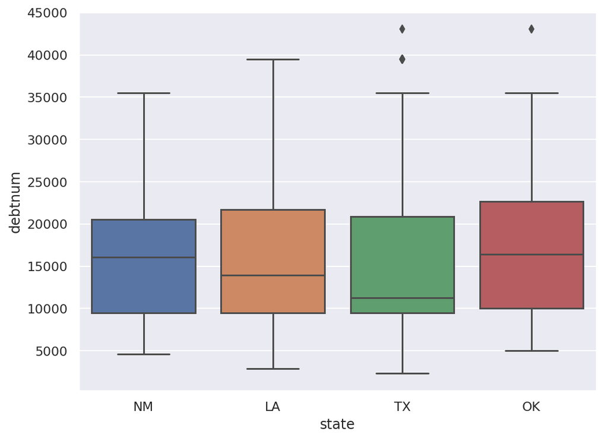

```python
import seaborn as sns
sns.set(style = "darkgrid")

sns.boxplot(x = 'state', y = 'debtnum', data = sw_debt_clean)
```

### Grouped visualization in `seaborn`

- **Faceting** or **small multiples**: breaking down a plot by a grouping variable into multiple plots

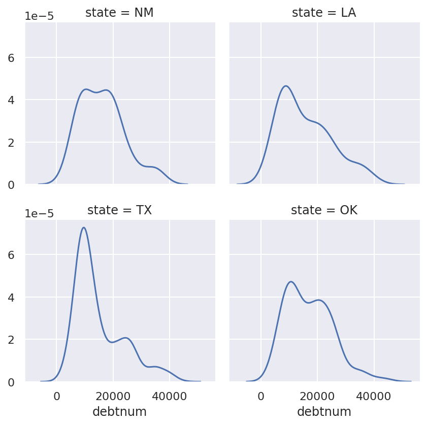

```python
grid = sns.FacetGrid(data = sw_debt_clean, col = 'state', col_wrap = 2)
grid.map(sns.kdeplot, 'debtnum')
```

### Merging data

- Commonly, you’ll have data in two - or multiple! - datasets that you’ll want to combine into one
- Simulated data:

```python
np.random.seed(123456)

m1 = pd.DataFrame({'type': ['a', 'b', 'c', 'd', 'e', 'f'],
                  'ind1': np.random.randint(1, 100, 6),
                  'ind2': np.random.randint(1, 100, 6)})

m2 = pd.DataFrame({'type': ['a', 'b', 'c', 'd', 'e', 'f'],
                  'ind3': np.random.randint(1, 100, 6),
                  'ind4': np.random.randint(1, 100, 6)})
```

### The `.merge()` method in `pandas`

```python
m3 = m1.merge(m2, on = 'type')
```

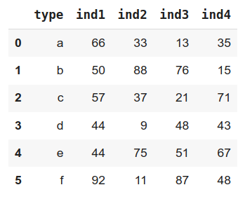

### Types of merges in `pandas`

- Options for merging (the `how` parameter): `'inner'` (default), `'left'`, `'right'`, and `'outer'`
- Simulated data:

```python
m4 = pd.DataFrame({'type': ['d', 'e', 'f', 'g', 'h', 'i'],
                  'ind5': np.random.randint(1, 100, 6),
                  'ind6': np.random.randint(1, 100, 6)})
```

### Inner merges

```python
m5 = m1.merge(m4, on = 'type', how = 'inner')
```

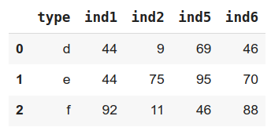

### Left merges

```python
m5 = m1.merge(m4, on = 'type', how = 'left')
```

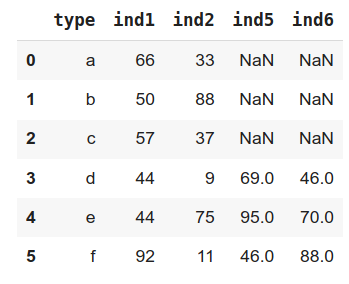

### Right merges

```python
m5 = m1.merge(m4, on = 'type', how = 'right')
```

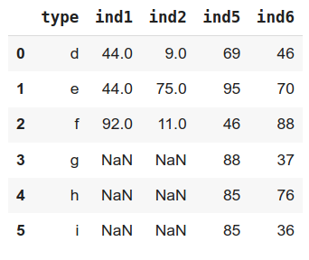

### Outer merges

```python
m5 = m1.merge(m4, on = 'type', how = 'outer')
```

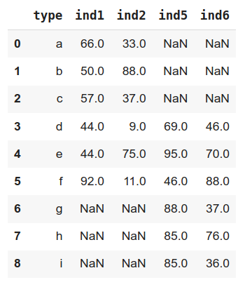

### The “shape” of data

- Long (“tidy”) data:
  - Each variable forms a column;
  - Each observation forms a row;
  - Each type of observational unit forms a table
- Wide data: column headers represent **values**, not variable names

### Example: World Bank data

- Long format:

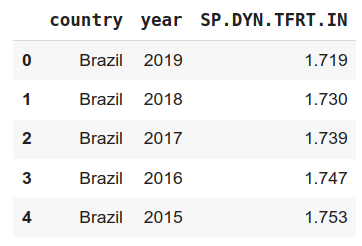

```python
from pandas_datareader import wb
countries = ['ZA', 'BR', 'US']
tfr = wb.download(indicator = 'SP.DYN.TFRT.IN',
                    country = countries, start = 1960,
                    end = 2019).reset_index()
tfr.head()
```

### Long to wide

- `.pivot()` method in `pandas`

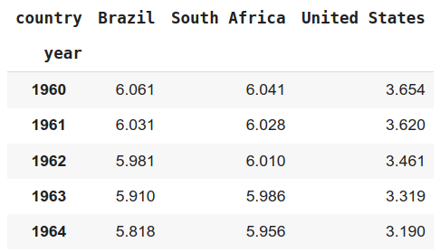

```python
tfr_wide = tfr.pivot(index = 'year', columns = 'country',
                    values = 'SP.DYN.TFRT.IN')

tfr_wide.head()
```

### Plotting “wide” data

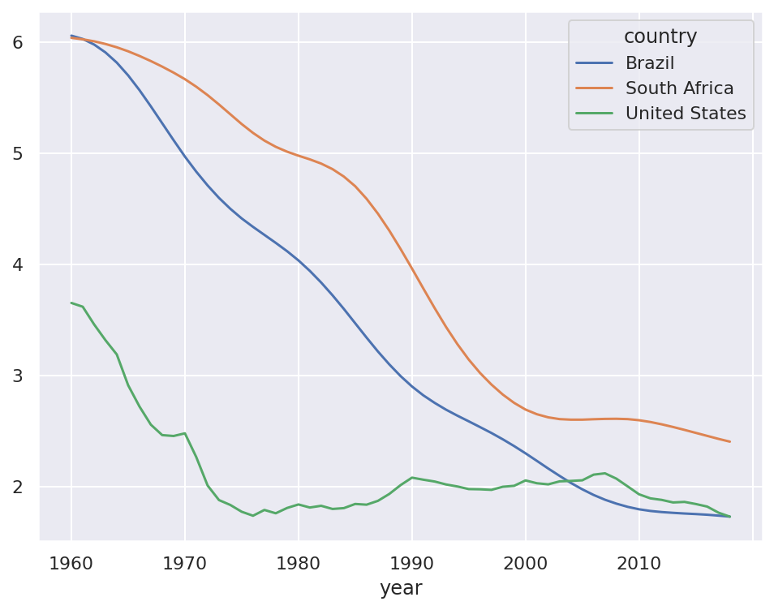

```python
tfr_wide.plot()
```

### Wide to long

- `pd.melt()` function in `pandas`

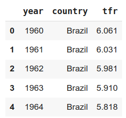

```python
tfr_long = pd.melt(tfr_wide.reset_index(), id_vars = 'year',
                   var_name = 'country', value_name = 'tfr')

tfr_long.head()
```

### Plotting long-form data

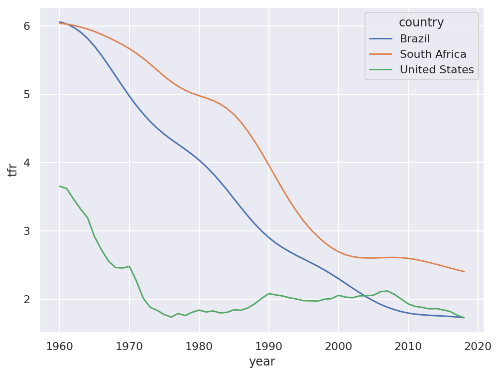

```python
tfr_long['year'] = tfr_long['year'].astype(int)
sns.lineplot(x = "year", y = "tfr",
            hue = "country", data = tfr_long)
```